# INFSCI 2595 Fall 2021 - Final Project

Part iii: Complete problem regression – iiiA)

Jianwei Liu

2021/11/6

```r
library(tidyverse)
```

```r
library(coefplot)
library(tidymodels)
library(glmnet)
library(nnet)
library(ranger)
library(xgboost)
library(kernlab)
library(finetune)
library(kknn)
library(torch)
if(parallel::detectCores(logical=FALSE) > 3){
  library(doParallel)

  num_cores <- parallel::detectCores(logical=FALSE)
  cl <- makePSOCKcluster(num_cores - 1)
  registerDoParallel(cl)
}
train_x <- readr::read_csv("train_input_set_x.csv", col_names = TRUE)
train_v <- readr::read_csv("train_input_set_v.csv", col_names = TRUE)
train_outputs <- readr::read_csv("train_outputs.csv", col_names = TRUE)
ready_x_A <- train_x %>%
  left_join(train_outputs, by = 'run_id') %>%
  select(-run_id, -outcome)
ready_v_A <- train_v %>%
  left_join(train_outputs, by = 'run_id') %>%
  select(-run_id, -outcome)
```

### predict the continuous output with respect to the “x-variables”

#### Linear additive features

```r
set.seed(2021)
cv_folds <- vfold_cv(ready_x_A, v = 5, repeats = 5)

cv_folds
```

```
## #  5-fold cross-validation repeated 5 times
## # A tibble: 25 x 3
##    splits             id      id2
##    <list>             <chr>   <chr>
##  1 <split [1519/380]> Repeat1 Fold1
##  2 <split [1519/380]> Repeat1 Fold2
##  3 <split [1519/380]> Repeat1 Fold3
##  4 <split [1519/380]> Repeat1 Fold4
##  5 <split [1520/379]> Repeat1 Fold5
##  6 <split [1519/380]> Repeat2 Fold1
##  7 <split [1519/380]> Repeat2 Fold2
##  8 <split [1519/380]> Repeat2 Fold3
##  9 <split [1519/380]> Repeat2 Fold4
## 10 <split [1520/379]> Repeat2 Fold5
## # ... with 15 more rows
```

Define Performance metrics:

```r
my_metrics <- metric_set(rmse, rsq, mae)
```

Define linear models specification:

```r
lm_spec <- linear_reg() %>% set_engine("lm")
```

Preprocess the additive model:

```r
bp_additive <- recipe(response ~ ., data = ready_x_A) %>%
  step_center(all_predictors()) %>%
  step_scale(all_predictors())

bp_additive
```

```
## Recipe
##
## Inputs:
##
##       role #variables
##    outcome          1
##  predictor         43
##
## Operations:
##
## Centering for all_predictors()
## Scaling for all_predictors()
```

Compile the model and pre-processing into a single workflow:

```r
additive_wflow <- workflow() %>%
  add_model(lm_spec) %>%
  add_recipe(bp_additive)
```

Execute the training and testing:

```r
lm_additive_res <- additive_wflow %>%
  fit_resamples(cv_folds, metrics = my_metrics
)

lm_additive_res %>% collect_metrics()
```

```
## # A tibble: 3 x 6
##   .metric .estimator  mean     n std_err .config
##   <chr>   <chr>      <dbl> <int>   <dbl> <chr>
## 1 mae     standard   0.325    25 0.00206 Preprocessor1_Model1
## 2 rmse    standard   0.409    25 0.00295 Preprocessor1_Model1
## 3 rsq     standard   0.728    25 0.00428 Preprocessor1_Model1
```

#### All pair-wise interactions between the inputs

Follow the same procedure:

```r
bp_pairs <- bp_additive %>%
  step_interact( ~ all_predictors():all_predictors())

lm_pairs_wflow <- workflow() %>%
  add_model(lm_spec) %>%
  add_recipe(bp_pairs)

lm_pairs_res <- lm_pairs_wflow %>%
  fit_resamples(cv_folds,
                metrics = my_metrics)

lm_pairs_res %>% collect_metrics()
```

```
## # A tibble: 3 x 6
##   .metric .estimator  mean     n std_err .config
##   <chr>   <chr>      <dbl> <int>   <dbl> <chr>
## 1 mae     standard   0.287    25 0.00272 Preprocessor1_Model1
## 2 rmse    standard   0.365    25 0.00323 Preprocessor1_Model1
## 3 rsq     standard   0.802    25 0.00414 Preprocessor1_Model1
```

#### All pair-wise interactions model in the simplified “Getting started” portion of the project.

```r
bp_pairs_small <- recipe(response ~ x07 + x09 + x10 + x11 + x21, data = ready_x_A) %>%
  step_center(all_predictors()) %>%
  step_scale(all_predictors()) %>%
  step_interact( ~ all_predictors():all_predictors())

lm_pairs_small_wflow <- workflow() %>%
  add_model(lm_spec) %>%
  add_recipe(bp_pairs_small)

lm_pairs_small_res <- lm_pairs_small_wflow %>%
  fit_resamples(cv_folds,
                metrics = my_metrics)

lm_pairs_small_res %>% collect_metrics()
```

```
## # A tibble: 3 x 6
##   .metric .estimator  mean     n std_err .config
##   <chr>   <chr>      <dbl> <int>   <dbl> <chr>
## 1 mae     standard   0.216    25 0.00186 Preprocessor1_Model1
## 2 rmse    standard   0.274    25 0.00265 Preprocessor1_Model1
## 3 rsq     standard   0.877    25 0.00280 Preprocessor1_Model1
```

Add the linear models to summary:

```r
all_cv_results <- lm_additive_res %>% collect_metrics(summarize = FALSE) %>%
  mutate(wflow_id = "lm_add") %>%
  bind_rows(lm_pairs_res %>% collect_metrics(summarize = FALSE) %>%
              mutate(wflow_id = "lm_pairs")) %>%
  bind_rows(lm_pairs_small_res %>% collect_metrics(summarize = FALSE) %>%
              mutate(wflow_id = "lm_pairs_small"))

all_cv_summaries  <- lm_additive_res %>% collect_metrics(summarize = TRUE) %>%
  mutate(wflow_id = "lm_add") %>%
  bind_rows(lm_pairs_res %>% collect_metrics(summarize = TRUE) %>%
              mutate(wflow_id = "lm_pairs")) %>%
  bind_rows(lm_pairs_small_res %>% collect_metrics(summarize = TRUE) %>%
              mutate(wflow_id = "lm_pairs_small"))
```

### Penalized regression - Elastic net

#### All pair-wise interactions between the inputs

First we define the search grid:

```r
my_lambda <- penalty(range = c(-10.5, 2), trans = log_trans())
my_alpha <- mixture(range = c(0.1, 1.0))
enet_grid <- grid_regular(my_lambda, my_alpha,
                          levels = c(penalty = 75, mixture = 5))

enet_grid %>% glimpse()
```

```
## Rows: 375
## Columns: 2
## $ penalty <dbl> 2.753645e-05, 3.260382e-05, 3.860371e-05, 4.570772e-05, 5.4119~
## $ mixture <dbl> 0.1, 0.1, 0.1, 0.1, 0.1, 0.1, 0.1, 0.1, 0.1, 0.1, 0.1, 0.1, 0.~
```

Then we define the elastic net model:

```r
enet_spec <- linear_reg(penalty = tune(), mixture = tune()) %>%
  set_engine("glmnet",
             # glmnet specific options
             intercept = TRUE, standardize.response = TRUE, standardize = TRUE,
             path_values = exp(seq(-10.5, 2, length.out = 75)))

enet_spec %>% translate()
```

```
## Linear Regression Model Specification (regression)
##
## Main Arguments:
##   penalty = tune()
##   mixture = tune()
##
## Engine-Specific Arguments:
##   intercept = TRUE
##   standardize.response = TRUE
##   standardize = TRUE
##
## Computational engine: glmnet
##
## Model fit template:
## glmnet::glmnet(x = missing_arg(), y = missing_arg(), weights = missing_arg(),
##     lambda = exp(seq(-10.5, 2, length.out = 75)), alpha = tune(),
##     intercept = TRUE, standardize.response = TRUE, standardize = TRUE,
##     family = "gaussian")
```

The workflow for all pair-wise interactions is defined below:

```r
enet_pairs_wflow <- workflow() %>%
  add_model(enet_spec) %>%
  add_recipe(bp_pairs)
```

Train and test the pairs elastic net:

```r
enet_pairs_res <- tune_grid(
  enet_pairs_wflow,
  resamples = cv_folds,
  grid = enet_grid,
  metrics = my_metrics
)
```

Visualize the result:

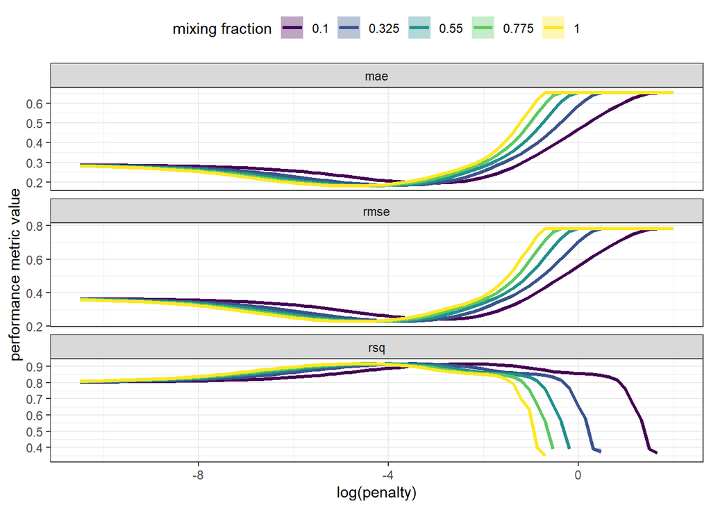

```r
enet_pairs_res %>% collect_metrics() %>%
  ggplot(mapping = aes(x = log(penalty))) +
  geom_ribbon(mapping = aes(ymin = mean - std_err,
                            ymax = mean + std_err,
                            group = interaction(mixture, .metric),
                            fill = as.factor(mixture)),
              alpha = 0.35) +
  geom_line(mapping = aes(y = mean,
                          group = interaction(mixture, .metric),
                          color = as.factor(mixture)),
            size = 1.15) +
  facet_wrap(~.metric, scales = "free_y", ncol = 1) +
  scale_fill_viridis_d("mixing fraction") +
  scale_color_viridis_d("mixing fraction") +
  labs(y = "performance metric value") +
  theme_bw() +
  theme(legend.position = "top")
```

Focus on RMSE and identify the best lambda using “1-standard error rule”:

```r
enet_pairs_res %>% select_by_one_std_err(desc(penalty), desc(mixture), metric = 'rmse')
```

```
## # A tibble: 1 x 10
##   penalty mixture .metric .estimator  mean     n std_err .config    .best .bound
##     <dbl>   <dbl> <chr>   <chr>      <dbl> <int>   <dbl> <chr>      <dbl>  <dbl>
## 1  0.0169    0.55 rmse    standard   0.229    25 0.00184 Preproces~ 0.228  0.230
```

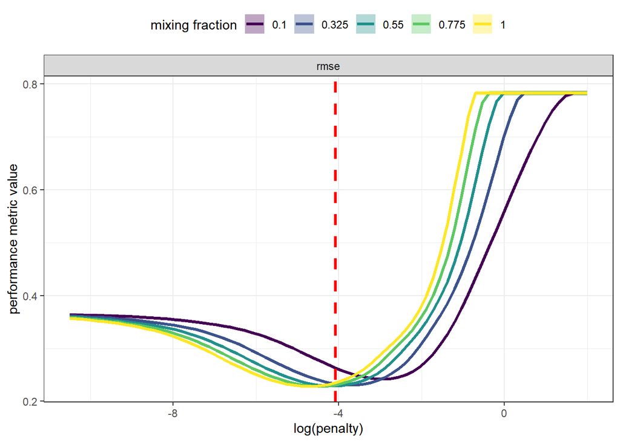

```r
enet_pairs_res %>% collect_metrics() %>%
  filter(.metric %in% c("rmse")) %>%
  ggplot(mapping = aes(x = log(penalty))) +
  geom_ribbon(mapping = aes(ymin = mean - std_err,
                            ymax = mean + std_err,
                            group = interaction(mixture, .metric),
                            fill = as.factor(mixture)),
              alpha = 0.35) +
  geom_line(mapping = aes(y = mean,
                          group = interaction(mixture, .metric),
                          color = as.factor(mixture)),
            size = 1.15) +
  geom_vline(data = enet_pairs_res %>% select_by_one_std_err(desc(penalty), desc(mixture), metric = 'rmse'),
             mapping = aes(xintercept = log(penalty)),
             color = 'red', linetype = 'dashed', size = 1.2) +
  facet_wrap(~.metric, scales = "free_y", ncol = 1) +
  scale_fill_viridis_d("mixing fraction") +
  scale_color_viridis_d("mixing fraction") +
  labs(y = 'performance metric value') +
  theme_bw() +
  theme(legend.position = "top")
```

Fit the pairs elastic net with the best tuning parameters:

```r
enet_pairs_lowest_rmse_params <- enet_pairs_res %>%
  select_by_one_std_err(desc(penalty), desc(mixture), metric = 'rmse') %>%
  select(all_of(names(enet_grid)))

final_enet_pairs_wflow <- enet_pairs_wflow %>%
  finalize_workflow(enet_pairs_lowest_rmse_params)

final_enet_pairs_fit <- final_enet_pairs_wflow %>%
  fit_resamples(cv_folds,
                metrics = my_metrics)
final_enet_pairs_fit %>% collect_metrics()
```

```
## # A tibble: 3 x 6
##   .metric .estimator  mean     n std_err .config
##   <chr>   <chr>      <dbl> <int>   <dbl> <chr>
## 1 mae     standard   0.183    25 0.00129 Preprocessor1_Model1
## 2 rmse    standard   0.229    25 0.00184 Preprocessor1_Model1
## 3 rsq     standard   0.916    25 0.00170 Preprocessor1_Model1
```

#### cubic RSM model in the simplified “Getting started” portion of the project

Create the cubic RSM model in the simplified “Getting started” portion of the project:

```r
bp_rsm3_small <- recipe(response ~ x07 + x09 + x10 + x11 + x21, data = ready_x_A) %>%
  step_center(all_predictors()) %>%
  step_scale(all_predictors()) %>%
  step_poly(all_predictors(), degree = 3,
            options = list(raw = TRUE)) %>%
  step_interact(~ends_with("_poly_1"):ends_with("_poly_1"):ends_with("_poly_1"))

lm_rsm3_small_wflow <- workflow() %>%
  add_model(lm_spec) %>%
  add_recipe(bp_rsm3_small)

lm_rsm3_small_res <- lm_rsm3_small_wflow %>%
  fit_resamples(cv_folds,
                metrics = my_metrics)

lm_rsm3_small_res %>% collect_metrics()
```

```
## # A tibble: 3 x 6
##   .metric .estimator  mean     n std_err .config
##   <chr>   <chr>      <dbl> <int>   <dbl> <chr>
## 1 mae     standard   0.194    25 0.00173 Preprocessor1_Model1
## 2 rmse    standard   0.248    25 0.00231 Preprocessor1_Model1
## 3 rsq     standard   0.899    25 0.00216 Preprocessor1_Model1
```

Train and test the rsm3 elastic net:

```r
enet_rsm3_wflow <- workflow() %>%
  add_model(enet_spec) %>%
  add_recipe(bp_rsm3_small)

enet_rsm3_res <- tune_grid(
  enet_rsm3_wflow,
  resamples = cv_folds,
  grid = enet_grid,
  metrics = my_metrics
)
```

Visualize the result:

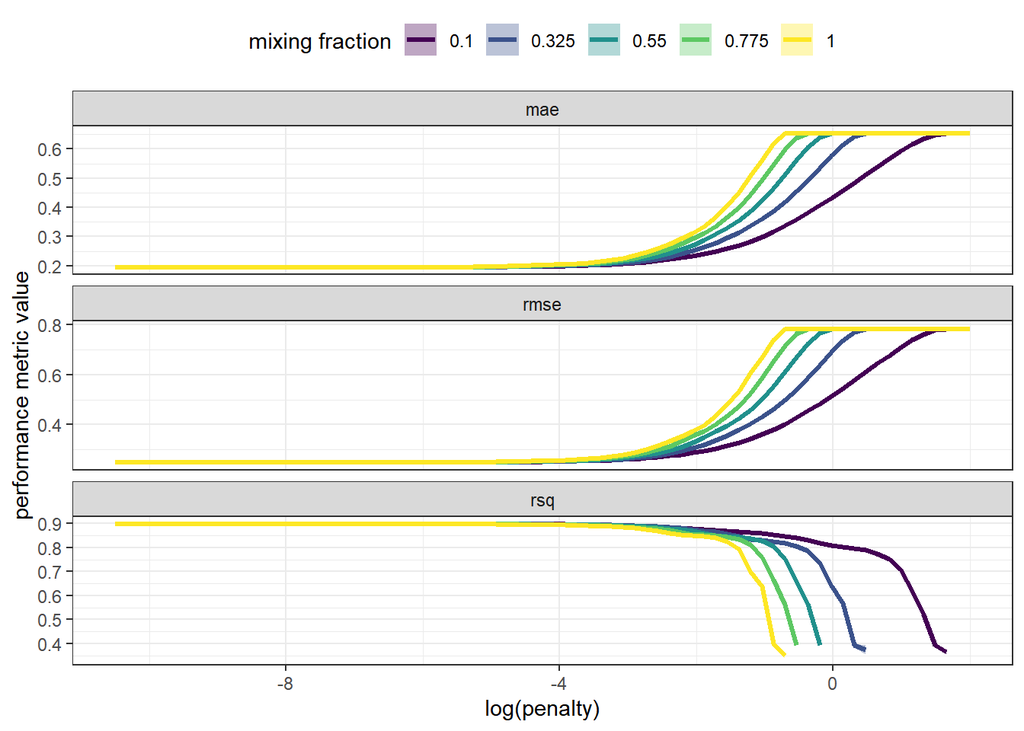

```r
enet_rsm3_res %>% collect_metrics() %>%
  ggplot(mapping = aes(x = log(penalty))) +
  geom_ribbon(mapping = aes(ymin = mean - std_err,
                            ymax = mean + std_err,
                            group = interaction(mixture, .metric),
                            fill = as.factor(mixture)),
              alpha = 0.35) +
  geom_line(mapping = aes(y = mean,
                          group = interaction(mixture, .metric),
                          color = as.factor(mixture)),
            size = 1.15) +
  facet_wrap(~.metric, scales = "free_y", ncol = 1) +
  scale_fill_viridis_d("mixing fraction") +
  scale_color_viridis_d("mixing fraction") +
  labs(y = "performance metric value") +
  theme_bw() +
  theme(legend.position = "top")
```

Focus on RMSE and identify the best lambda which minimize the RMSE:

```r
enet_rsm3_res %>% select_best(metric = 'rmse')
```

```
## # A tibble: 1 x 3
##   penalty mixture .config
##     <dbl>   <dbl> <chr>
## 1 0.00159       1 Preprocessor1_Model325
```

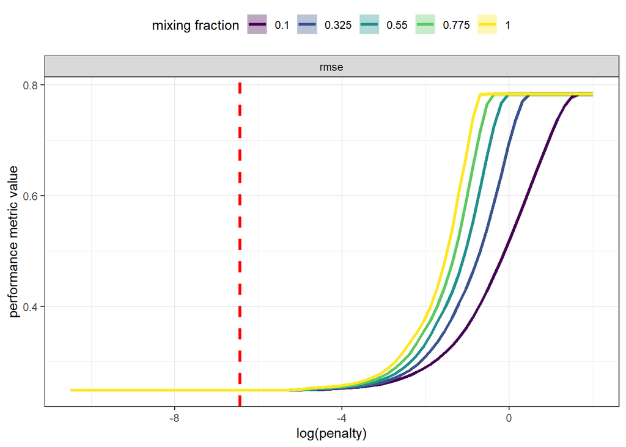

```r
enet_rsm3_res %>% collect_metrics() %>%
  filter(.metric %in% c("rmse")) %>%
  ggplot(mapping = aes(x = log(penalty))) +
  geom_ribbon(mapping = aes(ymin = mean - std_err,
                            ymax = mean + std_err,
                            group = interaction(mixture, .metric),
                            fill = as.factor(mixture)),
              alpha = 0.35) +
  geom_line(mapping = aes(y = mean,
                          group = interaction(mixture, .metric),
                          color = as.factor(mixture)),
            size = 1.15) +
  geom_vline(data = enet_rsm3_res %>% select_best(metric = 'rmse'),
             mapping = aes(xintercept = log(penalty)),
             color = 'red', linetype = 'dashed', size = 1.2) +
  facet_wrap(~.metric, scales = "free_y", ncol = 1) +
  scale_fill_viridis_d("mixing fraction") +
  scale_color_viridis_d("mixing fraction") +
  labs(y = 'performance metric value') +
  theme_bw() +
  theme(legend.position = "top")
```

Fit the rsm3 elastic net with the best tuning parameters:

```r
enet_rsm3_lowest_rmse_params <- enet_rsm3_res %>%
  select_best(metric = 'rmse') %>%
  select(all_of(names(enet_grid)))

final_enet_rsm3_wflow <- enet_rsm3_wflow %>%
  finalize_workflow(enet_rsm3_lowest_rmse_params)

final_enet_rsm3_fit <- final_enet_rsm3_wflow %>%
  fit_resamples(cv_folds,
                metrics = my_metrics)
final_enet_rsm3_fit %>% collect_metrics()
```

```
## # A tibble: 3 x 6
##   .metric .estimator  mean     n std_err .config
##   <chr>   <chr>      <dbl> <int>   <dbl> <chr>
## 1 mae     standard   0.194    25 0.00176 Preprocessor1_Model1
## 2 rmse    standard   0.248    25 0.00233 Preprocessor1_Model1
## 3 rsq     standard   0.900    25 0.00215 Preprocessor1_Model1
```

Add the result to all_cv_results:

```r
all_cv_results <- all_cv_results %>%
  bind_rows(enet_pairs_res %>% collect_metrics(summarize = FALSE) %>%
              mutate(wflow_id = "enet_pairs")) %>%
  bind_rows(enet_rsm3_res %>% collect_metrics(summarize = FALSE) %>%
              mutate(wflow_id = "enet_rsm3_small"))

all_cv_summaries <- all_cv_summaries %>%
  bind_rows(enet_pairs_res %>% collect_metrics(summarize = TRUE) %>%
              inner_join(enet_pairs_lowest_rmse_params %>%
                           mutate(keep_these = 'yes'),
                         by = names(enet_pairs_lowest_rmse_params)) %>%
              select(-keep_these) %>%
              mutate(wflow_id = "enet_pairs")) %>%
  bind_rows(enet_rsm3_res %>% collect_metrics(summarize = TRUE) %>%
              inner_join(enet_rsm3_lowest_rmse_params %>%
                           mutate(keep_these = 'yes'),
                         by = names(enet_rsm3_lowest_rmse_params)) %>%
              select(-keep_these) %>%
              mutate(wflow_id = "enet_rsm3_small"))
```

### neural network using Torch

Fisrt define the torch version of dataset:

```r
torch_dataset <- dataset(

  name = "torch_dataset",

  initialize = function(df) {
    self$data <- self$prepare_data(df)
  },

  .getitem = function(index) {

    x <- self$data[index, 1:-2]
    y <- self$data[index, -1]

    list(x, y)
  },

  .length = function() {
    self$data$size()[[1]]
  },

  prepare_data = function(df) {

    input <- na.omit(df)

    input <- as.matrix(input)
    torch_tensor(input)
  }
)
```

Split train and test with 70% and 30%:

```r
set.seed(2021)
train_indices <- sample(1:nrow(ready_x_A), round(nrow(ready_x_A)*0.7))

torch_train_ds <- torch_dataset(ready_x_A[train_indices, ])
torch_valid_ds <- torch_dataset(ready_x_A[setdiff(1:nrow(ready_x_A), train_indices), ])

length(torch_train_ds)
```

```
## [1] 1329
```

```r
length(torch_valid_ds)
```

```
## [1] 570
```

Define the data loader:

```r
train_dl <- torch_train_ds %>% dataloader(batch_size = 16, shuffle = TRUE)
valid_dl <- torch_valid_ds %>% dataloader(batch_size = 16, shuffle = FALSE)
valid_dl$.length()
```

```
## [1] 36
```

Define the network structure:

```r
torch_net <- nn_module(
  "regNet",
  initialize = function() {
    self$fc1 <- nn_linear(43, 64)
    self$fc2 <- nn_linear(64, 1)
  },
  forward = function(x) {
    x %>%
      self$fc1() %>%
      nnf_relu() %>%
      self$fc2()
  }
)

torch_model <- torch_net()
```

Train the model. The result has some problems. so I comment it out for now:

```
optimizer$zero_grad()
output <- torch_model(b[[1]])
loss <- nnf_nll_loss(output, b[[2]])

loss$backward()
optimizer$step()

train_losses <- c(train_losses, loss$item())
```

```
output <- torch_model(b[[1]])
loss <- nnf_nll_loss(output, b[[2]])
valid_losses <- c(valid_losses, loss$item())
```

### Neural Network

Build neural network using mlp:

```r
nnet_spec <- mlp(hidden_units = tune(), penalty = tune(), epochs = 1000) %>%
  set_engine("nnet", MaxNWts = 2500, trace=FALSE) %>%
  set_mode("regression")
```

Define neural network workflow:

```r
nnet_wflow <- workflow() %>%
  add_model(nnet_spec) %>%
  add_recipe(bp_additive)
```

Tune the model using Bayesian optimization:

```r
nn_set <- parameters(nnet_wflow)
#nn_set <- nn_set %>%
#  update(hidden_units = hidden_units(c(0L, 10L)),
#         penalty = penalty(c(-2L,2L)))

set.seed(2021)
nn_res <- nnet_wflow %>%
  tune_bayes(resamples = cv_folds,
             param_info = nn_set,
             initial = 5,
             iter = 10,
             metrics = my_metrics,
             control = control_bayes(no_improve = 30, verbose = TRUE))
```

```
## >  Generating a set of 5 initial parameter results
```

```
## √ Initialization complete
```

```
## Optimizing rmse using the expected improvement
```

```
## -- Iteration 1 -----------------------------------------------------------------
```

```
## i Current best:      rmse=0.1329 (@iter 0)
```

```
## i Gaussian process model
```

```
## √ Gaussian process model
```

```
## i Generating 5000 candidates
```

```
## i Predicted candidates
```

```
## i hidden_units=9, penalty=0.998
```

```
## i Estimating performance
```

```
## √ Estimating performance
```

```
## (x) Newest results:  rmse=0.1473 (+/-0.00188)
```

```
## -- Iteration 2 -----------------------------------------------------------------
```

```
## i Current best:      rmse=0.1329 (@iter 0)
```

```
## i Gaussian process model
```

```
## √ Gaussian process model
```

```
## i Generating 5000 candidates
```

```
## i Predicted candidates
```

```
## i hidden_units=8, penalty=0.96
```

```
## i Estimating performance
```

```
## √ Estimating performance
```

```
## (x) Newest results:  rmse=0.1459 (+/-0.00186)
```

```
## -- Iteration 3 -----------------------------------------------------------------
```

```
## i Current best:      rmse=0.1329 (@iter 0)
```

```
## i Gaussian process model
```

```
## √ Gaussian process model
```

```
## i Generating 5000 candidates
```

```
## i Predicted candidates
```

```
## i hidden_units=1, penalty=0.0548
```

```
## i Estimating performance
```

```
## √ Estimating performance
```

```
## (x) Newest results:  rmse=0.2653 (+/-0.00182)
```

```
## -- Iteration 4 -----------------------------------------------------------------
```

```
## i Current best:      rmse=0.1329 (@iter 0)
```

```
## i Gaussian process model
```

```
## √ Gaussian process model
```

```
## i Generating 5000 candidates
```

```
## i Predicted candidates
```

```
## i hidden_units=8, penalty=0.0537
```

```
## i Estimating performance
```

```
## √ Estimating performance
```

```
## <3 Newest results:   rmse=0.1241 (+/-0.0022)
```

```
## -- Iteration 5 -----------------------------------------------------------------
```

```
## i Current best:      rmse=0.1241 (@iter 4)
```

```
## i Gaussian process model
```

```
## √ Gaussian process model
```

```
## i Generating 5000 candidates
```

```
## i Predicted candidates
```

```
## i hidden_units=9, penalty=0.035
```

```
## i Estimating performance
```

```
## √ Estimating performance
```

```
## (x) Newest results:  rmse=0.1252 (+/-0.00181)
```

```
## -- Iteration 6 -----------------------------------------------------------------
```

```
## i Current best:      rmse=0.1241 (@iter 4)
```

```
## i Gaussian process model
```

```
## √ Gaussian process model
```

```
## i Generating 5000 candidates
```

```
## i Predicted candidates
```

```
## i hidden_units=10, penalty=1.06e-10
```

```
## i Estimating performance
```

```
## √ Estimating performance
```

```
## (x) Newest results:  rmse=0.2287 (+/-0.00954)
```

```
## -- Iteration 7 -----------------------------------------------------------------
```

```
## i Current best:      rmse=0.1241 (@iter 4)
```

```
## i Gaussian process model
```

```
## √ Gaussian process model
```

```
## i Generating 5000 candidates
```

```
## i Predicted candidates
```

```
## i hidden_units=9, penalty=0.0718
```

```
## i Estimating performance
```

```
## √ Estimating performance
```

```
## (x) Newest results:  rmse=0.1264 (+/-0.00161)
```

```
## -- Iteration 8 -----------------------------------------------------------------
```

```
## i Current best:      rmse=0.1241 (@iter 4)
```

```
## i Gaussian process model
```

```
## √ Gaussian process model
```

```
## i Generating 5000 candidates
```

```
## i Predicted candidates
```

```
## i hidden_units=8, penalty=0.0363
```

```
## i Estimating performance
```

```
## √ Estimating performance
```

```
## <3 Newest results:   rmse=0.1236 (+/-0.0019)
```

```
## -- Iteration 9 -----------------------------------------------------------------
```

```
## i Current best:      rmse=0.1236 (@iter 8)
```

```
## i Gaussian process model
```

```
## √ Gaussian process model
```

```
## i Generating 5000 candidates
```

```
## i Predicted candidates
```

```
## i hidden_units=7, penalty=0.0361
```

```
## i Estimating performance
```

```
## √ Estimating performance
```

```
## <3 Newest results:   rmse=0.1221 (+/-0.00177)
```

```
## -- Iteration 10 ----------------------------------------------------------------
```

```
## i Current best:      rmse=0.1221 (@iter 9)
```

```
## i Gaussian process model
```

```
## √ Gaussian process model
```

```
## i Generating 5000 candidates
```

```
## i Predicted candidates
```

```
## i hidden_units=10, penalty=0.0367
```

```
## i Estimating performance
```

```
## √ Estimating performance
```

```
## (x) Newest results:  rmse=0.1277 (+/-0.00166)
```

Visualize the result:

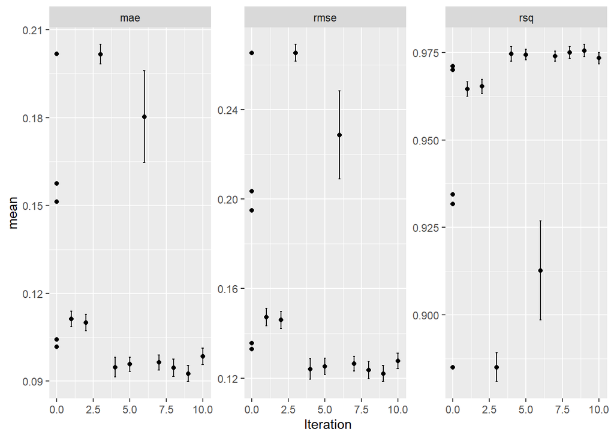

```r
autoplot(nn_res, type = "performance")
```

Find the best neural network model and fit on the train set:

```r
nn_lowest_rmse_params <- nn_res %>% select_best('rmse')

final_nn_wflow <- nnet_wflow %>%
  finalize_workflow(nn_lowest_rmse_params)

final_nn_fit <- final_nn_wflow %>%
  fit_resamples(cv_folds, metrics = my_metrics)
final_nn_fit %>% collect_metrics()
```

```
## # A tibble: 3 x 6
##   .metric .estimator   mean     n  std_err .config
##   <chr>   <chr>       <dbl> <int>    <dbl> <chr>
## 1 mae     standard   0.0967    25 0.00156  Preprocessor1_Model1
## 2 rmse    standard   0.127     25 0.00198  Preprocessor1_Model1
## 3 rsq     standard   0.974     25 0.000949 Preprocessor1_Model1
```

```r
final_nn_model <- final_nn_wflow %>%  fit(ready_x_A)
```

Add the result to summary:

```r
all_cv_summaries <- all_cv_summaries %>%
  bind_rows(nn_res %>% collect_metrics(summarize = TRUE) %>%
              inner_join(nn_lowest_rmse_params %>%
                           mutate(keep_these = 'yes'),
                         by = names(nn_lowest_rmse_params)) %>%
              select(-keep_these) %>%
              mutate(wflow_id = "nnet"))

all_cv_results <- all_cv_results %>%
  bind_rows(nn_res %>% collect_metrics(summarize = FALSE) %>%
              inner_join(nn_lowest_rmse_params %>%
                           mutate(keep_these = 'yes'),
                         by = names(nn_lowest_rmse_params)) %>%
              select(-keep_these) %>%
              mutate(wflow_id = "nnet"))
```

### Random forest

Define the model and the workflow:

```r
rf_spec <- rand_forest(mtry = tune(), min_n = tune(), trees = 1000) %>%
  set_engine("ranger") %>%
  set_mode('regression')

rf_wflow <- workflow() %>%
  add_model(rf_spec) %>%
  add_formula(response ~ .)
```

Tune the model using Bayesian optimization:

```r
rf_set <-  rf_spec %>% parameters() %>% finalize(ready_x_A)

set.seed(2021)
rf_res <- rf_wflow %>%
  tune_bayes(resamples = cv_folds,
             param_info = rf_set,
             metrics = my_metrics,
             initial = 5,
             iter = 10,
             control = control_bayes(no_improve = 5, verbose = TRUE))
```

```
## >  Generating a set of 5 initial parameter results
```

```
## √ Initialization complete
```

```
## Optimizing rmse using the expected improvement
```

```
## -- Iteration 1 -----------------------------------------------------------------
```

```
## i Current best:      rmse=0.2087 (@iter 0)
```

```
## i Gaussian process model
```

```
## √ Gaussian process model
```

```
## i Generating 1614 candidates
```

```
## i Predicted candidates
```

```
## i mtry=18, min_n=40
```

```
## i Estimating performance
```

```
## √ Estimating performance
```

```
## (x) Newest results:  rmse=0.2459 (+/-0.00143)
```

```
## -- Iteration 2 -----------------------------------------------------------------
```

```
## i Current best:      rmse=0.2087 (@iter 0)
```

```
## i Gaussian process model
```

```
## √ Gaussian process model
```

```
## i Generating 1617 candidates
```

```
## i Predicted candidates
```

```
## i mtry=34, min_n=2
```

```
## i Estimating performance
```

```
## √ Estimating performance
```

```
## <3 Newest results:   rmse=0.1996 (+/-0.00192)
```

```
## -- Iteration 3 -----------------------------------------------------------------
```

```
## i Current best:      rmse=0.1996 (@iter 2)
```

```
## i Gaussian process model
```

```
## √ Gaussian process model
```

```
## i Generating 1617 candidates
```

```
## i Predicted candidates
```

```
## i mtry=44, min_n=3
```

```
## i Estimating performance
```

```
## √ Estimating performance
```

```
## (x) Newest results:  rmse=0.2012 (+/-0.00203)
```

```
## -- Iteration 4 -----------------------------------------------------------------
```

```
## i Current best:      rmse=0.1996 (@iter 2)
```

```
## i Gaussian process model
```

```
## √ Gaussian process model
```

```
## i Generating 1615 candidates
```

```
## i Predicted candidates
```

```
## i mtry=41, min_n=2
```

```
## i Estimating performance
```

```
## √ Estimating performance
```

```
## (x) Newest results:  rmse=0.2003 (+/-0.00202)
```

```
## -- Iteration 5 -----------------------------------------------------------------
```

```
## i Current best:      rmse=0.1996 (@iter 2)
```

```
## i Gaussian process model
```

```
## √ Gaussian process model
```

```
## i Generating 1603 candidates
```

```
## i Predicted candidates
```

```
## i mtry=28, min_n=2
```

```
## i Estimating performance
```

```
## √ Estimating performance
```

```
## (x) Newest results:  rmse=0.2023 (+/-0.00177)
```

```
## -- Iteration 6 -----------------------------------------------------------------
```

```
## i Current best:      rmse=0.1996 (@iter 2)
```

```
## i Gaussian process model
```

```
## √ Gaussian process model
```

```
## i Generating 1608 candidates
```

```
## i Predicted candidates
```

```
## i mtry=39, min_n=2
```

```
## i Estimating performance
```

```
## √ Estimating performance
```

```
## (x) Newest results:  rmse=0.2001 (+/-0.002)
```

```
## -- Iteration 7 -----------------------------------------------------------------
```

```
## i Current best:      rmse=0.1996 (@iter 2)
```

```
## i Gaussian process model
```

```
## √ Gaussian process model
```

```
## i Generating 1603 candidates
```

```
## i Predicted candidates
```

```
## i mtry=1, min_n=35
```

```
## i Estimating performance
```

```
## √ Estimating performance
```

```
## (x) Newest results:  rmse=0.6795 (+/-0.00382)
```

```
## ! No improvement for 5 iterations; returning current results.
```

Visualize the result:

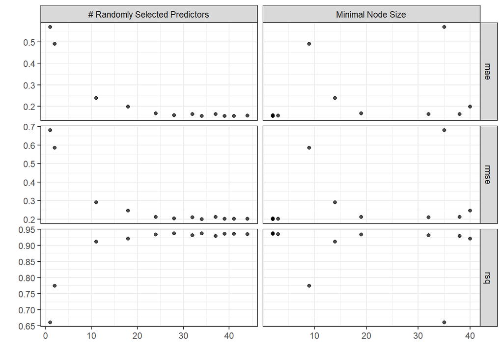

```r
rf_res %>% autoplot() + theme_bw()
```

Find the best random forest model and fit on the train set:

```r
rf_lowest_rmse_params <- rf_res %>% select_best('rmse')

final_rf_spec <- rand_forest(mtry = rf_lowest_rmse_params$mtry,
                              min_n = rf_lowest_rmse_params$min_n,
                              trees = 1000) %>%
  set_engine('ranger', importance = 'impurity') %>%
  set_mode('regression')

final_rf_wflow <- workflow() %>%
  add_model(final_rf_spec) %>%
  add_formula(response ~ .)

set.seed(2021)
final_rf_model <-  final_rf_wflow %>%  fit(ready_x_A)
```

Add to summary:

```r
all_cv_summaries <- all_cv_summaries %>%
  bind_rows(rf_res %>% collect_metrics(summarize = TRUE) %>%
              inner_join(rf_lowest_rmse_params %>%
                           mutate(keep_these = 'yes'),
                         by = names(rf_lowest_rmse_params)) %>%
              select(-keep_these) %>%
              mutate(wflow_id = "rf"))

all_cv_results <- all_cv_results %>%
  bind_rows(rf_res %>% collect_metrics(summarize = FALSE) %>%
              inner_join(rf_lowest_rmse_params %>%
                           mutate(keep_these = 'yes'),
                         by = names(rf_lowest_rmse_params)) %>%
              select(-keep_these) %>%
              mutate(wflow_id = "rf"))
```

### Gradient boosted trees

Create gradient boosted trees:

```r
xgb_spec <- boost_tree(tree_depth = tune(), learn_rate = tune(),
                       trees = tune(), mtry = tune(), sample_size = tune()) %>%
  set_engine("xgboost") %>%
  set_mode("regression")
```

Define workflow:

```r
xgb_wflow <- workflow() %>%
  add_model(xgb_spec) %>%
  add_formula(response ~ .)
```

Tune gradient boosted trees using Bayesian optimization:

```r
xgb_set <- xgb_wflow %>% parameters() %>% finalize(ready_x_A)

set.seed(2021)
xgb_res <- xgb_wflow %>%
  tune_bayes(resamples = cv_folds,
             param_info = xgb_set,
             initial = 5,
             iter = 10,
             metrics = my_metrics,
             control = control_bayes(no_improve = 5, verbose = TRUE))
```

```
## ! There are 5 tuning parameters and 5 grid points were requested. This is
##   likely to cause numerical issues in the first few search iterations.
```

```
## >  Generating a set of 5 initial parameter results
```

```
## √ Initialization complete
```

```
## Optimizing rmse using the expected improvement
```

```
## -- Iteration 1 -----------------------------------------------------------------
```

```
## i Current best:      rmse=0.1942 (@iter 0)
```

```
## i Gaussian process model
```

```
## ! The Gaussian process model is being fit using 5 features but only has 5
##   data points to do so. This may cause errors or a poor model fit.
```

```
## √ Gaussian process model
```

```
## i Generating 5000 candidates
```

```
## i Predicted candidates
```

```
## i mtry=32, trees=1810, tree_depth=5, learn_rate=0.0364, sample_size=0.175
```

```
## i Estimating performance
```

```
## √ Estimating performance
```

```
## <3 Newest results:   rmse=0.1747 (+/-0.00172)
```

```
## -- Iteration 2 -----------------------------------------------------------------
```

```
## i Current best:      rmse=0.1747 (@iter 1)
```

```
## i Gaussian process model
```

```
## ! The Gaussian process model is being fit using 5 features but only has 6
##   data points to do so. This may cause errors or a poor model fit.
```

```
## √ Gaussian process model
```

```
## i Generating 5000 candidates
```

```
## i Predicted candidates
```

```
## i mtry=13, trees=83, tree_depth=4, learn_rate=0.0151, sample_size=0.539
```

```
## i Estimating performance
```

```
## √ Estimating performance
```

```
## (x) Newest results:  rmse=0.4786 (+/-0.00401)
```

```
## -- Iteration 3 -----------------------------------------------------------------
```

```
## i Current best:      rmse=0.1747 (@iter 1)
```

```
## i Gaussian process model
```

```
## √ Gaussian process model
```

```
## i Generating 5000 candidates
```

```
## i Predicted candidates
```

```
## i mtry=25, trees=1998, tree_depth=6, learn_rate=0.0126, sample_size=0.516
```

```
## i Estimating performance
```

```
## √ Estimating performance
```

```
## <3 Newest results:   rmse=0.1574 (+/-0.00149)
```

```
## -- Iteration 4 -----------------------------------------------------------------
```

```
## i Current best:      rmse=0.1574 (@iter 3)
```

```
## i Gaussian process model
```

```
## √ Gaussian process model
```

```
## i Generating 5000 candidates
```

```
## i Predicted candidates
```

```
## i mtry=19, trees=1757, tree_depth=7, learn_rate=0.0156, sample_size=0.571
```

```
## i Estimating performance
```

```
## √ Estimating performance
```

```
## (x) Newest results:  rmse=0.1712 (+/-0.00145)
```

```
## -- Iteration 5 -----------------------------------------------------------------
```

```
## i Current best:      rmse=0.1574 (@iter 3)
```

```
## i Gaussian process model
```

```
## √ Gaussian process model
```

```
## i Generating 5000 candidates
```

```
## i Predicted candidates
```

```
## i mtry=11, trees=1992, tree_depth=8, learn_rate=0.00814, sample_size=0.859
```

```
## i Estimating performance
```

```
## √ Estimating performance
```

```
## (x) Newest results:  rmse=0.2239 (+/-0.00141)
```

```
## -- Iteration 6 -----------------------------------------------------------------
```

```
## i Current best:      rmse=0.1574 (@iter 3)
```

```
## i Gaussian process model
```

```
## √ Gaussian process model
```

```
## i Generating 5000 candidates
```

```
## i Predicted candidates
```

```
## i mtry=44, trees=1804, tree_depth=10, learn_rate=0.00733, sample_size=0.982
```

```
## i Estimating performance
```

```
## √ Estimating performance
```

```
## (x) Newest results:  rmse=0.1955 (+/-0.0017)
```

```
## -- Iteration 7 -----------------------------------------------------------------
```

```
## i Current best:      rmse=0.1574 (@iter 3)
```

```
## i Gaussian process model
```

```
## √ Gaussian process model
```

```
## i Generating 5000 candidates
```

```
## i Predicted candidates
```

```
## i mtry=28, trees=1669, tree_depth=4, learn_rate=0.0135, sample_size=0.727
```

```
## i Estimating performance
```

```
## √ Estimating performance
```

```
## (x) Newest results:  rmse=0.1594 (+/-0.00161)
```

```
## -- Iteration 8 -----------------------------------------------------------------
```

```
## i Current best:      rmse=0.1574 (@iter 3)
```

```
## i Gaussian process model
```

```
## √ Gaussian process model
```

```
## i Generating 5000 candidates
```

```
## i Predicted candidates
```

```
## i mtry=31, trees=1950, tree_depth=11, learn_rate=0.0176, sample_size=0.816
```

```
## i Estimating performance
```

```
## √ Estimating performance
```

```
## (x) Newest results:  rmse=0.1779 (+/-0.00185)
```

```
## ! No improvement for 5 iterations; returning current results.
```

Visualize the result:

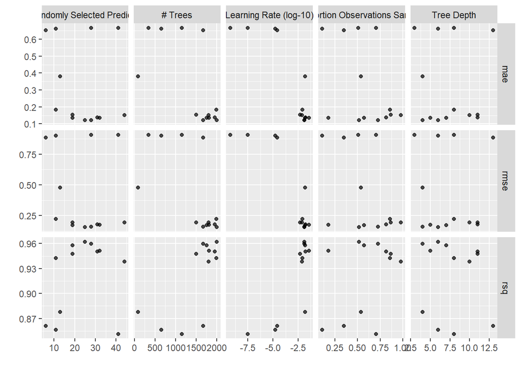

```r
autoplot(xgb_res)
```

Find the best gradient boosted trees model and fit on the train set:

```r
xgb_lowest_rmse_params <- xgb_res %>% select_best('rmse')

final_xgb_wflow <- xgb_wflow %>%
  finalize_workflow(xgb_lowest_rmse_params)

set.seed(2021)
final_xgb_fit <- final_xgb_wflow %>%  fit(ready_x_A)
```

Add to summary:

```r
all_cv_summaries <- all_cv_summaries %>%
  bind_rows(xgb_res %>% collect_metrics(summarize = TRUE) %>%
              inner_join(xgb_lowest_rmse_params %>%
                           mutate(keep_these = 'yes'),
                         by = names(xgb_lowest_rmse_params)) %>%
              select(-keep_these) %>%
              mutate(wflow_id = "xgb"))

all_cv_results <- all_cv_results %>%
  bind_rows(xgb_res %>% collect_metrics(summarize = FALSE) %>%
              inner_join(xgb_lowest_rmse_params %>%
                           mutate(keep_these = 'yes'),
                         by = names(xgb_lowest_rmse_params)) %>%
              select(-keep_these) %>%
              mutate(wflow_id = "xgb"))
```

### Support Vector Machine (SVM)

Define SVM model and workflow:

```r
svm_rbf_spec <- svm_rbf(cost = tune(), rbf_sigma = tune(), margin = tune()) %>%
  set_engine("kernlab") %>%
  set_mode("regression")

svm_rbf_wflow <- workflow() %>%
  add_model(svm_rbf_spec) %>%
  add_recipe(bp_additive)
```

Tune SVM using racing with ANOVA:

```r
rbf_grid <- crossing(rbf_sigma = c(0.01, 0.05, 0.1, 0.2, 0.4, 0.8, 1.25, 1.5),
                     cost = c(0.01, 0.1, 1, 10, 100),
                     margin = c(0.01, 0.05, 0.1, 1.0))

#set.seed(2021)
#svm_rbf_res <- tune_grid(
#  svm_rbf_wflow,
#  resamples = cv_folds,
#  grid = rbf_grid,
#  metrics = my_metrics
#)

set.seed(2021)
svm_rbf_res <- tune_race_anova(
  svm_rbf_wflow,
  resamples = cv_folds,
  grid = rbf_grid,
  metrics = my_metrics
)
```

Visualize the result:

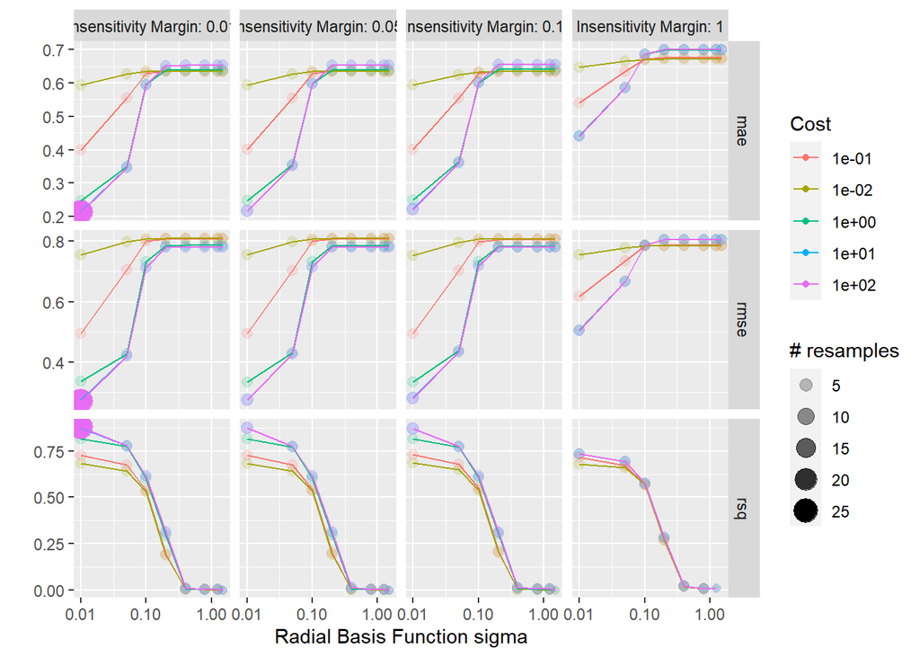

```r
autoplot(svm_rbf_res)
```

Identify the best tuning parameters and fit the final model:

```r
svm_lowest_rmse_params <- svm_rbf_res %>% select_best('rmse')

final_svm_rbf_wflow  <- svm_rbf_wflow  %>%
  finalize_workflow(svm_lowest_rmse_params)

set.seed(2021)
final_svm_fit <- final_svm_rbf_wflow %>%  fit(ready_x_A)
```

Add to summary:

```r
all_cv_summaries <- all_cv_summaries %>%
  bind_rows(svm_rbf_res %>% collect_metrics(summarize = TRUE) %>%
              inner_join(svm_lowest_rmse_params %>%
                           mutate(keep_these = 'yes'),
                         by = names(svm_lowest_rmse_params)) %>%
              select(-keep_these) %>%
              mutate(wflow_id = "svm rbf"))

all_cv_results <- all_cv_results %>%
  bind_rows(svm_rbf_res %>% collect_metrics(summarize = FALSE) %>%
              inner_join(svm_lowest_rmse_params %>%
                           mutate(keep_these = 'yes'),
                         by = names(svm_lowest_rmse_params)) %>%
              select(-keep_these) %>%
              mutate(wflow_id = "svm rbf"))
```

### K-nearest neighbors

Create model and workflow:

```r
knn_spec <- nearest_neighbor(neighbors = tune(), weight_func = tune()) %>%
  set_mode("regression") %>%
  set_engine("kknn")

knn_wflow <- workflow() %>%
  add_model(knn_spec) %>%
  add_formula(response ~ .)
```

Tune KNN using racing with ANOVA:

```r
knn_grid <- crossing(neighbors = seq(1,50),
                     weight_func = c("rectangular", "triangular", "epanechnikov", "biweight", "triweight", "cos", "inv", "gaussian", "rank", "optimal"))

set.seed(2021)
knn_res <- tune_race_anova(
  knn_wflow,
  resamples = cv_folds,
  grid = knn_grid,
  metrics = my_metrics
)
```

Visualize the result:

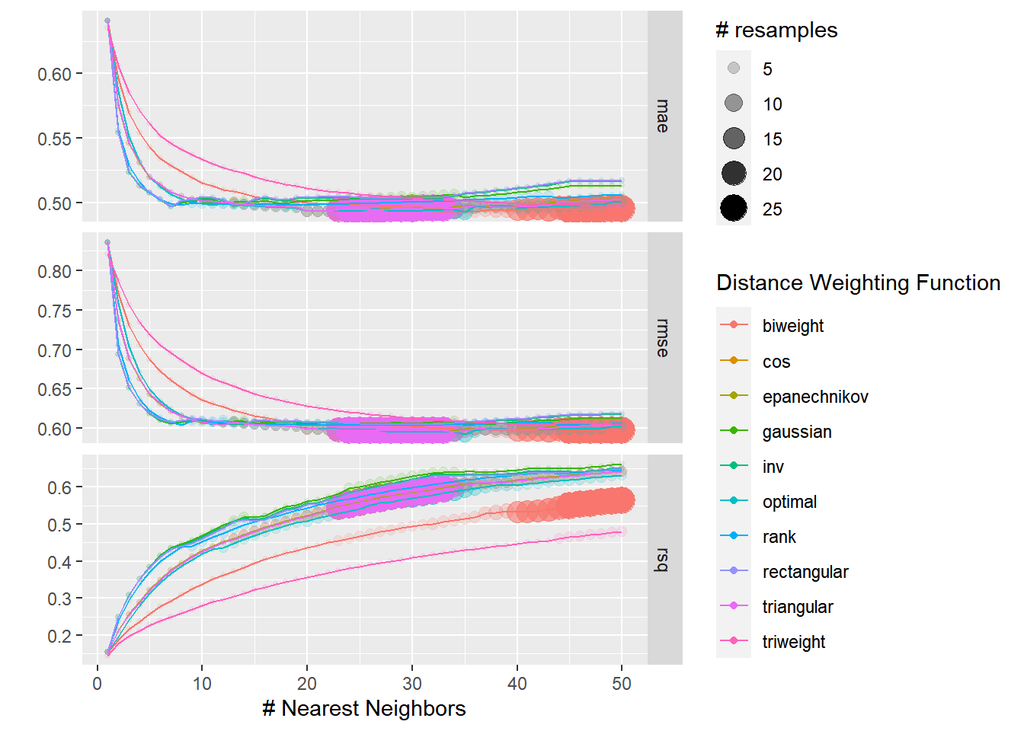

```r
autoplot(knn_res)
```

Identify the best tuning parameters and fit the final model:

```r
knn_lowest_rmse_params <- knn_res %>% select_best('rmse')

final_knn_wflow  <- knn_wflow  %>%
  finalize_workflow(knn_lowest_rmse_params)

set.seed(2021)
final_knn_fit <- final_knn_wflow %>%  fit(ready_x_A)

final_knn_fit <- final_knn_wflow %>%
  fit_resamples(cv_folds,
                metrics = my_metrics)
final_knn_fit %>% collect_metrics()
```

```
## # A tibble: 3 x 6
##   .metric .estimator  mean     n std_err .config
##   <chr>   <chr>      <dbl> <int>   <dbl> <chr>
## 1 mae     standard   0.495    25 0.00292 Preprocessor1_Model1
## 2 rmse    standard   0.597    25 0.00352 Preprocessor1_Model1
## 3 rsq     standard   0.569    25 0.00429 Preprocessor1_Model1
```

```r
knn_lowest_rmse_params
```

```
## # A tibble: 1 x 3
##   neighbors weight_func .config
##       <int> <chr>       <chr>
## 1        27 triangular  Preprocessor1_Model427
```

Add to summary:

```r
all_cv_summaries <- all_cv_summaries %>%
  bind_rows(knn_res %>% collect_metrics(summarize = TRUE) %>%
              inner_join(knn_lowest_rmse_params %>%
                           mutate(keep_these = 'yes'),
                         by = names(knn_lowest_rmse_params)) %>%
              select(-keep_these) %>%
              mutate(wflow_id = "knn rbf"))

all_cv_results <- all_cv_results %>%
  bind_rows(knn_res %>% collect_metrics(summarize = FALSE) %>%
              inner_join(knn_lowest_rmse_params %>%
                           mutate(keep_these = 'yes'),
                         by = names(knn_lowest_rmse_params)) %>%
              select(-keep_these) %>%
              mutate(wflow_id = "knn rbf"))
```

### Model comparison

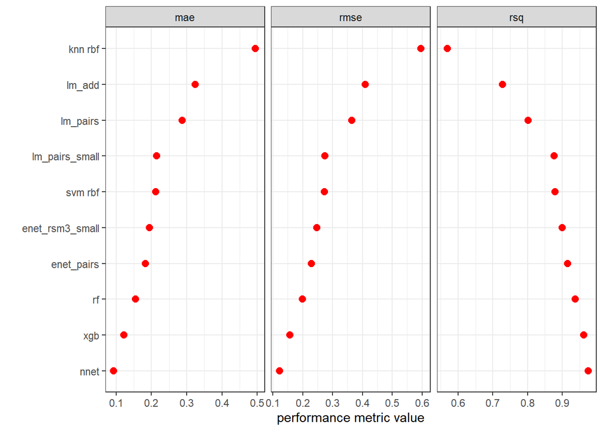

```r
all_cv_summaries %>%
  mutate(wflow_id = forcats::fct_reorder(wflow_id, mean, min)) %>%
  ggplot(mapping = aes(x = wflow_id)) +
  geom_linerange(mapping = aes(ymin = mean - 2*std_err,
                               ymax = mean + 2*std_err,
                               group = interaction(.metric, wflow_id)),
                 color = 'grey', size = 1.) +
  geom_linerange(mapping = aes(ymin = mean - 1*std_err,
                               ymax = mean + 1*std_err,
                               group = interaction(.metric, wflow_id)),
                 color = 'red', size = 1.2) +
  geom_point(mapping = aes(y = mean),
             color = 'red', size = 2.5) +
  coord_flip() +
  facet_wrap(~.metric, scales = "free_x") +
  labs(y = "performance metric value", x ="") +
  theme_bw()
```

From the plot we can see the neural network model performs the best base on MAE, RMSE and R-Squared.

Save the best model:

```r
final_nn_model %>% readr::write_rds("neural_network_regression_x.rds")
```